# R pour les sciences marines — niveau intermédiaire

Partie 2 · Séances I5 à I8 — Conditions, boucles, fonctions, maîtriser ggplot2

Aroo Falinirina

## Au programme

- **I5** : conditions (`if`, `ifelse`, `case_when`) et boucles (`for`, `sapply`)
- **I6** : écrire ses propres fonctions
- **I7** : ggplot2 (1) : échelles, couleurs, facettes, thèmes
- **I8** : ggplot2 (2) : moyennes ± IC, séries temporelles, annotations, patchwork

~12 min I5 · ~12 min I6 · ~18 min I7 · ~18 min I8.

## I5 — Conditions et boucles

## Une décision ou une colonne entière ?

```r
n <- sum(!is.na(seaweed$sgr))
if (n < 30) message("petit échantillon") else message("n = ", n, " : ok")
```

```
#> n = 2317 : ok
```

```r
seaweed$growth <- ifelse(seaweed$sgr >= 3.5, "good", "low")      # vectorisé
seaweed$growth_cl <- case_when(seaweed$sgr < 3 ~ "low",
                               seaweed$sgr < 4 ~ "medium",
                               TRUE ~ "high")                    # tous les autres cas
table(seaweed$growth_cl, useNA = "ifany")
```

```
#>
#>   high    low medium
#>    731    615   1229
```

`if ()` attend **un seul** TRUE/FALSE ; pour une colonne : `ifelse()` ou `case_when()`.

## Une boucle `for`

```r
villages <- sort(unique(seaweed$village))
res <- numeric(length(villages))                  # conteneur vide
for (i in seq_along(villages)) {
  v <- seaweed[seaweed$village == villages[i], ]
  res[i] <- mean(v$sgr, na.rm = TRUE)
}
round(setNames(res, villages), 2)[1:6]
```

```
#>  Ambalakely Ambatofotsy  Ampasimena   Andrevobe    Ankarabe   Antsiraka
#>        3.34        3.43        3.42        3.46        3.32        3.26
```

## La même chose, plus court

```r
round(sapply(split(seaweed$sgr, seaweed$village), mean, na.rm = TRUE), 2)[1:6]
```

```
#>  Ambalakely Ambatofotsy  Ampasimena   Andrevobe    Ankarabe   Antsiraka
#>        3.34        3.43        3.42        3.46        3.32        3.26
```

- `split()` coupe un vecteur par groupe → une liste
- `sapply()` applique une fonction à chaque élément
- `for` reste utile pour **fabriquer des fichiers** : une figure, un tableau par village

```r
for (v in villages) {
  p <- ggplot(seaweed[seaweed$village == v, ], aes(planting_date, sgr)) + geom_point()
  ggsave(file.path("outputs", paste0("sgr_", v, ".png")), p, width = 16, height = 10, units = "cm")
}
```

## I6 — Fonctions

## Écrire une fonction

```r
sgr <- function(w0, w1, days) {
  if (any(w0 <= 0, na.rm = TRUE)) stop("les poids doivent être positifs")
  100 * (log(w1) - log(w0)) / days          # la dernière valeur est renvoyée
}
sgr(10, 45, 45)                                # test à la main : 100 * ln(4.5) / 45
```

```
#> [1] 3.342394
```

```r
se <- function(x) sd(x, na.rm = TRUE) / sqrt(sum(!is.na(x)))
se(seaweed$sgr)
```

```
#> [1] 0.0138348
```

Règle : dès que vous copiez-collez le même code **trois fois**, écrivez une fonction.

## Fonctions + groupes

```r
describe <- function(x) c(n = sum(!is.na(x)), mean = mean(x, na.rm = TRUE),
                          sd = sd(x, na.rm = TRUE), se = se(x))
round(describe(seaweed$sgr), 3)
```

```
#>        n     mean       sd       se
#> 2317.000    3.439    0.666    0.014
```

```r
seaweed %>% group_by(technique) %>%
  summarise(n = sum(!is.na(sgr)), mean = mean(sgr, na.rm = TRUE), se = se(sgr))
```

```
#> # A tibble: 2 × 4
#>   technique      n  mean     se
#>   <chr>      <int> <dbl>  <dbl>
#> 1 long-line   1064  3.69 0.0193
#> 2 off-bottom  1253  3.23 0.0175
```

## I7 — ggplot2 (1)

## La grammaire, rappel

`ggplot(données, aes(x, y, colour = ...))` + `geom_*()` + `scale_*()` + `labs()` + `theme_*()` + `facet_*()`

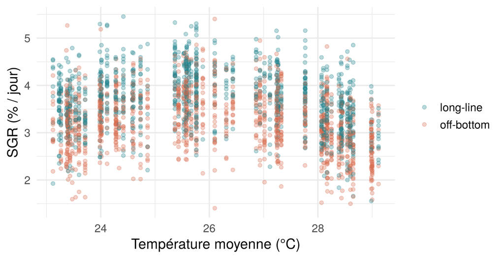

```r
ggplot(seaweed, aes(temp_mean, sgr, colour = technique)) +
  geom_point(alpha = 0.3, na.rm = TRUE) +
  scale_colour_manual(values = c("long-line" = "#1b7f8c", "off-bottom" = "#d9694a")) +
  labs(x = "Température moyenne (°C)", y = "SGR (% / jour)", colour = NULL)
```

## Échelles et couleurs

| But | Fonction |
| --- | --- |
| couleurs choisies | `scale_colour_manual(values = c(...))` |
| palettes prêtes | `scale_*_brewer()`, `scale_*_viridis_d/c()` (daltoniens) |
| graduations | `scale_y_continuous(breaks = ...)` |
| dates | `scale_x_date(date_breaks = "3 months", date_labels = "%b %Y")` |
| zoomer sans couper | `coord_cartesian(ylim = c(2, 5))` |

`ylim()` / `limits =` **supprime** les points hors limites avant les calculs (boxplots faux) ; `coord_cartesian()` zoome seulement.

## Facettes

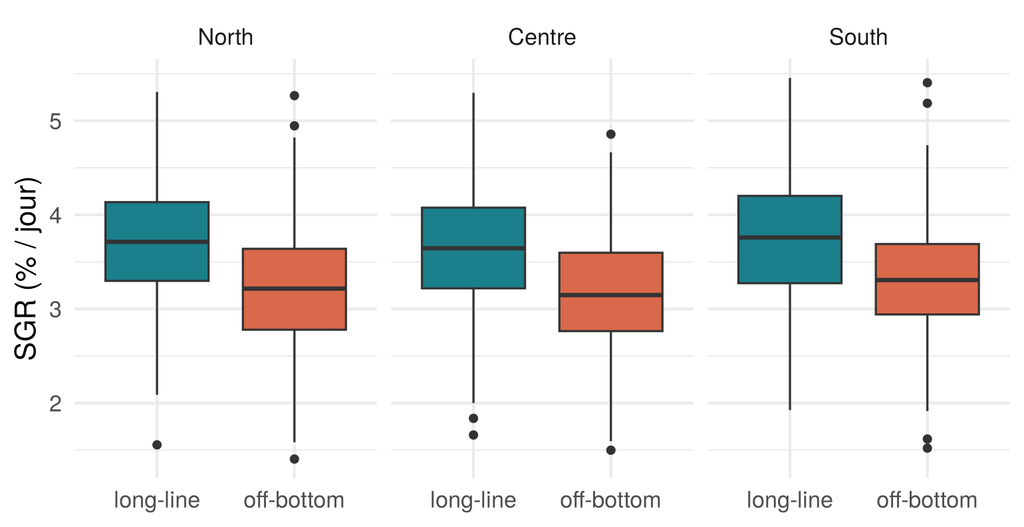

```r
ggplot(seaweed, aes(technique, sgr, fill = technique)) +
  geom_boxplot(na.rm = TRUE, show.legend = FALSE) +
  facet_wrap(~ zone) +
  scale_fill_manual(values = c("#1b7f8c", "#d9694a")) + labs(x = NULL, y = "SGR (% / jour)")
```

## Thèmes

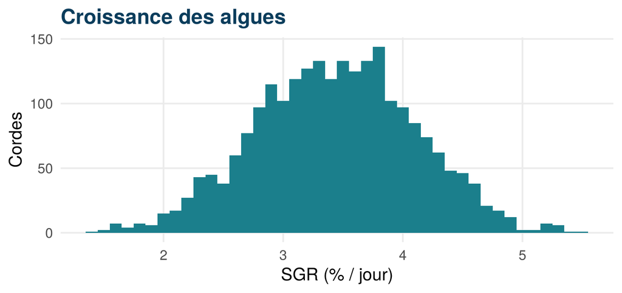

```r
theme_coop <- function(size = 14) {                 # votre thème = une fonction (I6)
  theme_minimal(base_size = size) +
    theme(legend.position = "top", panel.grid.minor = element_blank(),
          plot.title = element_text(face = "bold", colour = "#0b3d5c"))
}
ggplot(seaweed, aes(sgr)) + geom_histogram(binwidth = 0.1, fill = "#1b7f8c", na.rm = TRUE) +
  labs(title = "Croissance des algues", x = "SGR (% / jour)", y = "Cordes") + theme_coop()
```

## I8 — ggplot2 (2)

## Moyennes ± IC à 95 %

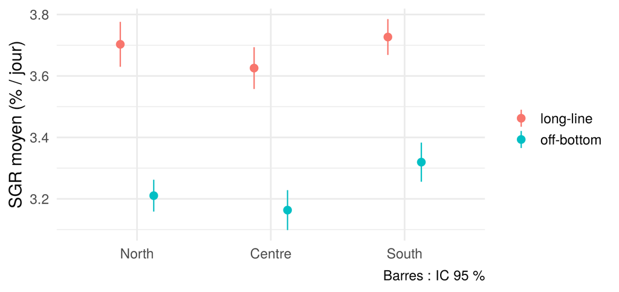

```r
summ <- seaweed %>% group_by(zone, technique) %>%
  summarise(m = mean(sgr, na.rm = TRUE), se = se(sgr), .groups = "drop")
ggplot(summ, aes(zone, m, colour = technique)) +
  geom_pointrange(aes(ymin = m - 1.96 * se, ymax = m + 1.96 * se),
                  position = position_dodge(width = 0.5)) +
  labs(x = NULL, y = "SGR moyen (% / jour)", colour = NULL, caption = "Barres : IC 95 %")
```

## Séries temporelles

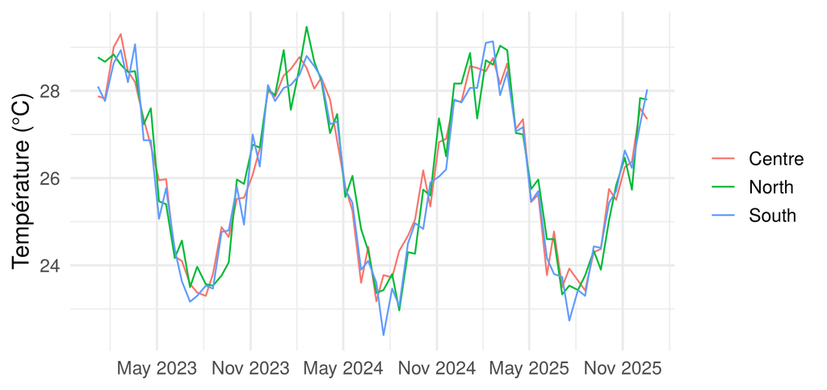

```r
st <- read.csv("data/stations.csv")
wz <- wq %>% left_join(st[, c("station", "zone")], by = "station") %>%
  group_by(zone, date) %>% summarise(temp = mean(temp_C, na.rm = TRUE), .groups = "drop")
ggplot(wz, aes(date, temp, colour = zone)) + geom_line() +
  scale_x_date(date_breaks = "6 months", date_labels = "%b %Y") +
  labs(x = NULL, y = "Température (°C)", colour = NULL)
```

## Ordonner et annoter

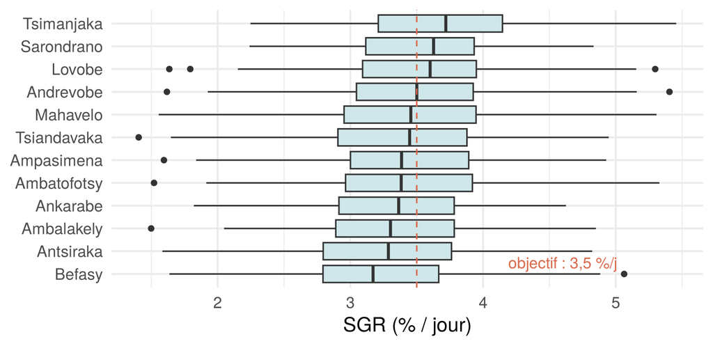

```r
ggplot(seaweed, aes(reorder(village, sgr, median, na.rm = TRUE), sgr)) +
  geom_boxplot(fill = "#cfe7ea", na.rm = TRUE) + coord_flip() +
  geom_hline(yintercept = 3.5, linetype = 2, colour = "#d9694a") +
  annotate("text", x = 1.5, y = 4.6, label = "objectif : 3,5 %/j", colour = "#d9694a") +
  labs(x = NULL, y = "SGR (% / jour)")
```

## Combiner avec patchwork

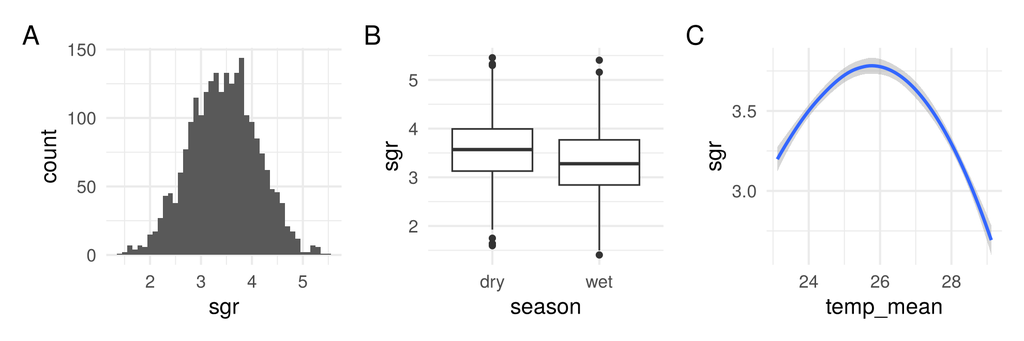

```r
pA <- ggplot(seaweed, aes(sgr)) + geom_histogram(binwidth = 0.1, na.rm = TRUE)
pB <- ggplot(seaweed, aes(season, sgr)) + geom_boxplot(na.rm = TRUE)
pC <- ggplot(seaweed, aes(temp_mean, sgr)) + geom_smooth(method = "loess", formula = y ~ x, na.rm = TRUE)
(pA | pB | pC) + plot_annotation(tag_levels = "A")
```

```r
# ggsave("outputs/figure_1.png", width = 18, height = 8, units = "cm", dpi = 300)
```

## À retenir — partie 2

- `if` pour une décision, `ifelse()` / `case_when()` pour une colonne
- `for` pour répéter et produire des fichiers ; `sapply(split())` pour résumer
- une fonction = du code réutilisable et testé
- un bon graphique : bonnes **échelles**, couleurs lisibles, **légende avec unités**, IC indiqués
- `coord_cartesian()` pour zoomer, `patchwork` pour assembler, `ggsave()` pour exporter

**À faire** : séances I5 à I8 en ligne, avec leurs quiz.

## Lire une échelle de couleur

`scale_fill_viridis_c(option = "mako", direction = -1, name = "SGR moyen")`

| Élément | Sens |
| --- | --- |
| `scale_fill_…` | règle l’esthétique `fill` (`scale_colour_…` pour `colour`) |
| `viridis` | palette lisible par les daltoniens et en gris |
| `_c` | variable **c**ontinue (`_d` : catégories) |
| `option` | `"viridis"`, `"magma"`, `"plasma"`, `"mako"`… |
| `direction` | `1` défaut, `-1` inverse (valeurs hautes foncées) |
| `name` | titre de la légende (`"\n"` = retour à la ligne) |

- épaisseur : `linewidth` (lignes) mais `size` (points, texte)
- type de trait : `linetype` (ggplot2) = `lty` (R de base)